# derfinder users guide

# 9 Miscellaneous features

In this section we go over some other features of *[derfinder](http://bioconductor.org/packages/release/bioc/html/derfinder.html)* which can be useful for performing feature-counts based analyses, exploring the results, or exporting data.

## 9.1 Feature level analysis

Similar to the expressed-region level analysis, you might be interested in performing a feature level analysis. More specifically, this means getting a count matrix at the exon level (or gene level). `coverageToExon()` allows you to get such a matrix by taking advantage of the summarized annotation produced by `makeGenomicState()`.

In this example, we use the genomic state included in the package which has the information for chr21 *[TxDb.Hsapiens.UCSC.hg19.knownGene](http://bioconductor.org/packages/release/data/annotation/html/TxDb.Hsapiens.UCSC.hg19.knownGene.html)* annotation.

```r
## Get the exon level matrix
system.time(exonCov <- coverageToExon(fullCov, genomicState$fullGenome, L = 76))
```

```
## class: SerialParam
##   bplog:FALSE; bpthreshold:INFO
##   bpcatchErrors:FALSE
## class: SerialParam
##   bplog:FALSE; bpthreshold:INFO
##   bpcatchErrors:FALSE
```

```
## 2015-11-11 18:50:05 coverageToExon: processing chromosome chr21
```

```
## class: SerialParam
##   bplog:FALSE; bpthreshold:INFO
##   bpcatchErrors:FALSE
```

```
## 2015-11-11 18:50:10 coverageToExon: processing chromosome chr21
```

```
##    user  system elapsed
##   8.924   2.814  11.864
```

```r
## Dimensions of the matrix
dim(exonCov)
```

```
## [1] 2658   12
```

```r
## Explore a little bit
tail(exonCov)
```

```
##         HSB113      HSB123      HSB126      HSB130       HSB135
## 4983 0.1173684   0.1382895   0.0000000   0.0000000   0.07894737
## 4985 4.6542105   1.4557895   1.6034210   0.7798684   1.29592103
## 4986 7.1510526 291.0205261 252.4892106 152.1905258 439.69500020
## 4988 0.0000000   0.7063158   0.7223684   0.2639474   0.48657895
## 4990 2.3064474  64.9423686  69.6584212  35.5769737 101.76394746
## 4992 0.1652632   8.1834211   9.7538158   2.4193421  10.08618420
##            HSB136       HSB145     HSB153      HSB159    HSB178
## 4983   0.03947368 5.263158e-03  0.1052632  0.04934211 0.1289474
## 4985   0.72986842 9.964474e-01 10.4906578  4.39013167 7.3119736
## 4986 263.63486853 2.345414e+02  4.5310526 10.64368415 4.9807895
## 4988   0.37657895 6.156579e-01  0.0000000  0.00000000 0.0000000
## 4990  76.96736838 5.978842e+01  1.2284210  2.67486840 0.9542105
## 4992  14.41013157 5.325658e+00  0.2402632  0.73039474 0.2601316
##            HSB92       HSB97
## 4983  0.03986842  0.44605264
## 4985  1.65184211 10.87723678
## 4986 11.40447366  6.23315790
## 4988  0.05644737  0.00000000
## 4990  3.98013159  1.96131579
## 4992  0.66907895  0.07473684
```

With this matrix, rounded if necessary, you can proceed to use packages such as *[limma](http://bioconductor.org/packages/release/bioc/html/limma.html)*, *[DESeq2](http://bioconductor.org/packages/release/bioc/html/DESeq2.html)*, *[edgeR](http://bioconductor.org/packages/release/bioc/html/edgeR.html)* among others.

## 9.2 Compare results visually

We can certainly make region level plots using `plotRegionCoverage()` or cluster plots using `plotCluster()` or overview plots using `plotOveview()`, all from *[derfinderPlot](http://bioconductor.org/packages/release/bioc/html/derfinderPlot.html)*.

First we need to get the relevant annotation information.

```r
## Annotate regions as exonic, intronic or intergenic
system.time(annoGenome <- annotateRegions(regionMat$chr21$regions, genomicState$fullGenome))
```

```
## 2015-11-11 18:50:14 annotateRegions: counting
## 2015-11-11 18:50:14 annotateRegions: annotating
```

```
##    user  system elapsed
##   0.288   0.004   0.292
```

```r
## Note that the genomicState object included in derfinder only has information
## for chr21 (hg19).

## Identify closest genes to regions
suppressPackageStartupMessages(library('bumphunter'))
suppressPackageStartupMessages(library('TxDb.Hsapiens.UCSC.hg19.knownGene'))
txdb <- TxDb.Hsapiens.UCSC.hg19.knownGene
genes <- annotateTranscripts(txdb)
```

```
## No annotationPackage supplied. Trying org.Hs.eg.db.
## Getting TSS and TSE.
## Getting CSS and CSE.
## Getting exons.
## Annotating genes.
```

```r
system.time(annoNear <- matchGenes(regionMat$chr21$regions, genes))
```

```
##    user  system elapsed
##   5.294   0.058   5.383
```

```r
## Identify the top regions by highest total coverage
top <- order(regionMat$chr21$regions$area, decreasing = TRUE)[1:100]

## Base-level plots for the top 100 regions with transcript information
library('derfinderPlot')
plotRegionCoverage(regionMat$chr21$regions, regionCoverage = regionMat$chr21$bpCoverage, groupInfo = pheno$group, nearestAnnotation = annoNear, annotatedRegions = annoGenome, whichRegions = top, scalefac = 1, txdb = txdb, ask = FALSE)
```

However, we can alternatively use *[epivizr](http://bioconductor.org/packages/release/bioc/html/epivizr.html)* to view the candidate DERs and the region matrix results in a genome browser.

```r
## Load epivizr, it's available from Bioconductor
library('epivizr')

## Load data to your browser
mgr <- startEpiviz()
ders_dev <- mgr$addDevice(
    fullRegions[as.logical(fullRegions$significantFWER) ], "Candidate DERs")
ders_potential_dev <- mgr$addDevice(
    fullRegions[!as.logical(fullRegions$significantFWER) ], "Potential DERs")
regs_dev <- mgr$addDevice(regionMat$chr21$regions, "Region Matrix")

## Go to a place you like in the genome
mgr$navigate("chr21", start(regionMat$chr21$regions[top[1]]) - 100, end(regionMat$chr21$regions[top[1]]) + 100)

## Stop the navigation
mgr$stopServer()
```

## 9.3 Export coverage to BigWig files

*[derfinder](http://bioconductor.org/packages/release/bioc/html/derfinder.html)* also includes `createBw()` with related functions `createBwSample()` and `coerceGR()` to export the output of `fullCoverage()` to BigWig files. These functions can be useful in the case where you start with BAM files and later on want to save the coverage data into BigWig files, which are generally smaller.

```r
## Subset only the first sample
fullCovSmall <- lapply(fullCov, '[', 1)

## Export to BigWig
bw <- createBw(fullCovSmall)
```

```
## 2015-11-11 18:50:45 coerceGR: coercing sample HSB113
## 2015-11-11 18:50:45 createBwSample: exporting bw for sample HSB113
```

```r
## See the file. Note that the sample name is used to name the file.
dir(pattern = '.bw')
```

```
## [1] "HSB113.bw"    "meanChr21.bw"
```

```r
## Internally createBw() coerces each sample to a GRanges object before
## exporting to a BigWig file. If more than one sample was exported, the
## GRangesList would have more elements.
bw
```

```
## GRangesList object of length 1:
## $HSB113
## GRanges object with 155950 ranges and 1 metadata column:
##         seqnames               ranges strand   |              score
##            <Rle>            <IRanges>  <Rle>   |          <numeric>
##   chr21    chr21   [9458667, 9458741]      *   | 0.0399999991059303
##   chr21    chr21   [9540957, 9540971]      *   | 0.0399999991059303
##   chr21    chr21   [9543719, 9543778]      *   | 0.0399999991059303
##   chr21    chr21   [9651480, 9651554]      *   | 0.0399999991059303
##   chr21    chr21   [9653397, 9653471]      *   | 0.0399999991059303
##     ...      ...                  ...    ... ...                ...
##   chr21    chr21 [48093246, 48093255]      *   | 0.0399999991059303
##   chr21    chr21 [48093257, 48093331]      *   | 0.0399999991059303
##   chr21    chr21 [48093350, 48093424]      *   | 0.0399999991059303
##   chr21    chr21 [48112194, 48112268]      *   | 0.0399999991059303
##   chr21    chr21 [48115056, 48115130]      *   | 0.0399999991059303
##
## -------
## seqinfo: 1 sequence from an unspecified genome
```

# 10 Advanced arguments

If you are interested in using advanced arguments in *[derfinder](http://bioconductor.org/packages/release/bioc/html/derfinder.html)*, use `advancedArg()` as shown below:

```r
## URLs to advanced arguemtns
sapply(c('analyzeChr', 'loadCoverage'), advancedArg, browse = FALSE)
```

```
##                                                                                                                             analyzeChr
## "https://github.com/search?utf8=%E2%9C%93&q=advanced_argument+filename%3Aanalyze+repo%3Alcolladotor%2Fderfinder+path%3A%2FR&type=Code"
##                                                                                                                           loadCoverage
##    "https://github.com/search?utf8=%E2%9C%93&q=advanced_argument+filename%3Aload+repo%3Alcolladotor%2Fderfinder+path%3A%2FR&type=Code"
```

```r
## Set browse = TRUE if you want to open them in your browser
```

The most common advanced arguments are:

- `chrsStyle` (default is `UCSC`)
- `verbose` (by default `TRUE`).

`verbose` controls whether to print status updates for nearly all the functions. `chrsStyle` is used to determine the chromosome naming style and is powered by *[GenomeInfoDb](http://bioconductor.org/packages/release/bioc/html/GenomeInfoDb.html)*. Note that `chrsStyle` is used in any of the functions that call `extendedMapSeqlevels()`. If you are working with a different organism than *Homo sapiens* set the global `species` option using `options(species = 'your species')` with the syntax used in `names(GenomeInfoDb::genomeStyles())`.

The third commonly used advanced argument is `mc.cores`. It controls the number of cores to use for the functions that can run with more than one core to speed up. In nearly all the cases, the maximum number of cores depends on the number of chromosomes. One notable exception is `analyzeChr()` where the maximum number of cores depends on the `chunksize` used and the dimensions of the data for the chromosome under study.

These advanced arguments are options we expect not all users will want to change and which would otherwise make the help pages confusing to them. However, all arguments are documented in *[roxygen2](http://cran.fhcrc.org/web/packages/roxygen2/index.html)* style in the source code.

Furthermore, note that using the `...` argument allows you to specify some of the documented arguments. For example, you might want to control the `maxClusterGap` from `findRegions()` in the `analyzeChr()` call.

# 11 Non-human data

If you are working with data from an organism that is not *Homo sapiens*, then set the global options defining the `species` and the `chrsStyle` used. For example, if you are working with *Arabidopsis Thaliana* and the *NCBI* naming style, then set the options using the following code:

```r
## Set global species and chrsStyle options
options(species = 'arabidopsis_thaliana')
options(chrsStyle = 'NCBI')

## Then proceed to load and analyze the data
```

Internally *[derfinder](http://bioconductor.org/packages/release/bioc/html/derfinder.html)* uses `extendedMapSeqlevels()` to use the appropriate chromosome naming style given a species in all functions involving chromosome names.

Further note that the argument `txdb` from `analyzeChr()` is passed to `bumphunter::annotateNearest(txdb)`. So if you are using a genome different from **hg19** remember to provide the appropriate annotation data or simply use `analyzeChr(runAnnotation = FALSE)`.

So, in the *Arabidopsis Thaliana* example, your `analyzeChr()` call would look like this:

```r
## Load transcript database information
library('TxDb.Athaliana.BioMart.plantsmart28')

## Set organism options
options(species = 'arabidopsis_thaliana')
options(chrsStyle = 'NCBI')

## Run command
analyzeChr(txdb = TxDb.Athaliana.BioMart.plantsmart28, --Other arguments--)
```

You might find the discussion [Using bumphunter with non-human genomes](https://support.bioconductor.org/p/62781/) useful.

# 12 Functions that use multiple cores

Currently, the following functions can use multiple cores, several of which are called inside `analyzeChr()`.

- `calculatePvalues()`: 1 core per chunk of data to process.
- `calculateStats()`: 1 core per chunk of data to process.
- `coerceGR()`: 1 core per chromosome. This function is used by `createBw()`.
- `coverageToExon()`: 1 core per strand, then 1 core per chromosome.
- `loadCoverage()`: up to 1 core per tile when loading the data with [GenomicFiles](http://www.bioconductor.org/packages/release/bioc/html/GenomicFiles.html). Otherwise, no parallelization is used.
- `fullCoverage()`: 1 core per chromosome. In general, try to avoid using more than 10 cores as you might reach your maximum network speed and/or hard disk input/output seed. For the case described in `loadCoverage()`, you can specify how many cores to use per chromosome for the tiles using the `mc.cores.load` argument effectively resulting in `mc.cores` times `mc.cores.load` used (otherwise it’s `mc.cores` squared).
- `getRegionCoverage()`: 1 core per chromosome.
- `regionMatrix()`: 1 core per chromosome.
- `railMatrix()`: 1 core per chromosome.

All parallel operations use `SnowParam()` from *[BiocParallel](http://bioconductor.org/packages/release/bioc/html/BiocParallel.html)* when more than 1 core is being used. Otherwise, `SerialParam()` is used. Note that if you prefer to specify other types of parallelization you can do so by specifying the `BPPARAM.custom` advanced argument.

Because `SnowParam()` requires `R` to load the necessary packages on each worker, the key function `fstats.apply()` was isolated in the *[derfinderHelper](http://bioconductor.org/packages/release/bioc/html/derfinderHelper.html)* package. This package has much faster loading speeds than *[derfinder](http://bioconductor.org/packages/release/bioc/html/derfinder.html)* which greatly impacts performance on cases where the actual step of calculating the F-statistics is fast.

You may prefer to use `MulticoreParam()` described in the *[BiocParallel](http://bioconductor.org/packages/release/bioc/html/BiocParallel.html)* vignette. In that case, when using these functions use `BPPARAM.custom = MulticoreParam(workers = x)` where `x` is the number of cores you want to use. Note that in some systems, as is the case of the cluster used by *[derfinder](http://bioconductor.org/packages/release/bioc/html/derfinder.html)*’s developers, the system tools for assessing memory usage can be misleading, thus resulting in much higher memory loads when using `MulticoreParam()` instead of the default `SnowParam()`.

# 13 Advanced loading data

## 13.1 Controlling loading from BAM files

If you are loading data from BAM files, you might want to specify some criteria to decide which reads to include or not. For example, your data might have been generated by a strand-specific protocol. You can do so by specifying the arguments of `scanBamFlag()` from *[Rsamtools](http://bioconductor.org/packages/release/bioc/html/Rsamtools.html)*.

You can also control whether to include or exclude bases with `CIGAR` string `D` (deletion from the reference) by setting the advanced argument `drop.D = TRUE` in your `fullCoverage()` or `loadCoverage()` call.

## 13.2 Unfiltered base-level coverage

Note that in most scenarios, the `fullCov` object illustrated in the introductory vignette can be large in memory. When making plots or calculating the region level coverage, we don’t need the full information. In such situations, it might pay off to create a smaller version by loading only the required data. This can be achieved using the advanced argument `which` to `fullCoverage()` or `loadCoverage()`.

However, it is important to consider that when reading the data from BAM files, a read might align partially inside the region of interest. By default such a read would be discarded and thus the base-level coverage would be lower than what it is in reality. The advanced argument `protectWhich` extends regions by 30 kbp (15 kbp each side) to help mitigate this issue.

We can illustrate this issue with the example data from *[derfinder](http://bioconductor.org/packages/release/bioc/html/derfinder.html)*. First, we load in the data and generate some regions of interest.

```r
## Find some regions to work with
example('loadCoverage', 'derfinder')
```

```
##
## ldCvrg> datadir <- system.file('extdata', 'genomeData', package='derfinder')
##
## ldCvrg> files <- rawFiles(datadir = datadir, samplepatt = '*accepted_hits.bam$',
## ldCvrg+     fileterm = NULL)
##
## ldCvrg> ## Shorten the column names
## ldCvrg> names(files) <- gsub('_accepted_hits.bam', '', names(files))
##
## ldCvrg> ## Read and filter the data, only for 2 files
## ldCvrg> dataSmall <- loadCoverage(files = files[1:2], chr = '21', cutoff = 0)
```

```
## 2015-11-11 18:50:46 loadCoverage: finding chromosome lengths
## 2015-11-11 18:50:46 loadCoverage: loading BAM file /Library/Frameworks/R.framework/Versions/3.2/Resources/library/derfinder/extdata/genomeData/ERR009101_accepted_hits.bam
## 2015-11-11 18:50:46 loadCoverage: loading BAM file /Library/Frameworks/R.framework/Versions/3.2/Resources/library/derfinder/extdata/genomeData/ERR009102_accepted_hits.bam
## 2015-11-11 18:50:46 loadCoverage: applying the cutoff to the merged data
## 2015-11-11 18:50:46 filterData: originally there were 48129895 rows, now there are 454 rows. Meaning that 100 percent was filtered.
```

```
##
## ldCvrg> ## Not run:
## ldCvrg> ##D ## Export to BigWig files
## ldCvrg> ##D createBw(list('chr21' = dataSmall))
## ldCvrg> ##D
## ldCvrg> ##D ## Load data from BigWig files
## ldCvrg> ##D dataSmall.bw <- loadCoverage(c(ERR009101 = 'ERR009101.bw', ERR009102 =
## ldCvrg> ##D     'ERR009102.bw'), chr = 'chr21')
## ldCvrg> ##D
## ldCvrg> ##D ## Compare them
## ldCvrg> ##D mapply(function(x, y) { x - y }, dataSmall$coverage, dataSmall.bw$coverage)
## ldCvrg> ##D
## ldCvrg> ##D ## Note that the only difference is the type of Rle (integer vs numeric) used
## ldCvrg> ##D ## to store the data.
## ldCvrg> ##D
## ldCvrg> ## End(Not run)
## ldCvrg>
## ldCvrg>
## ldCvrg>
```

```r
example('getRegionCoverage', 'derfinder')
```

```
##
## gtRgnC> ## Obtain fullCov object
## gtRgnC> fullCov <- list('21'=genomeDataRaw$coverage)
##
## gtRgnC> ## Assign chr lengths using hg19 information, use only first two regions
## gtRgnC> library('GenomicRanges')
##
## gtRgnC> data(hg19Ideogram, package = 'biovizBase', envir = environment())
##
## gtRgnC> regions <- genomeRegions$regions[1:2]
##
## gtRgnC> seqlengths(regions) <- seqlengths(hg19Ideogram)[names(seqlengths(regions))]
##
## gtRgnC> ## Finally, get the region coverage
## gtRgnC> regionCov <- getRegionCoverage(fullCov=fullCov, regions=regions)
```

```
## extendedMapSeqlevels: sequence names mapped from NCBI to UCSC for species homo_sapiens
## 2015-11-11 18:50:46 getRegionCoverage: processing chr21
## 2015-11-11 18:50:46 getRegionCoverage: done processing chr21
```

Next, we load the coverage again using `which` but without any padding. We can see how the coverage is not the same by looking at the maximum coverage for each sample.

```r
## Illustrate reading data from a set of regions
test <- loadCoverage(files = files, chr = '21', cutoff = NULL, which = regions, protectWhich = 0, fileStyle = 'NCBI')
```

[output not shown]

```r
## Some reads were ignored and thus the coverage is lower as can be seen below:
sapply(test$coverage, max) - sapply(genomeDataRaw$coverage, max)
```

```
## ERR009101 ERR009102 ERR009105 ERR009107 ERR009108 ERR009112 ERR009115
##         0         0         0         0        -1         0        -1
## ERR009116 ERR009131 ERR009138 ERR009144 ERR009145 ERR009148 ERR009151
##        -2        -2        -2        -1        -1        -3        -3
## ERR009152 ERR009153 ERR009159 ERR009161 ERR009163 ERR009164 ERR009167
##         0        -3        -3        -3        -1        -3        -3
## SRR031812 SRR031835 SRR031867 SRR031868 SRR031900 SRR031904 SRR031914
##         0        -1         0         0         0        -1         0
## SRR031936 SRR031958 SRR031960
##         0         0         0
```

When we re-load the data using some padding to the regions, we find that the coverage matches at all the bases.

```r
## Illustrate reading data from a set of regions

test2 <- loadCoverage(files = files, chr = '21', cutoff = NULL, which =
regions, protectWhich = 3e4, fileStyle = 'NCBI')
```

[output not shown]

```r
## Adding some padding to the regions helps get the same coverage
identical(sapply(test2$coverage, max), sapply(genomeDataRaw$coverage, max))
```

```
## [1] TRUE
```

```r
## A more detailed test reveals that the coverage matches at every base
all(mapply(function(x, y) { identical(x, y) }, test2$coverage, genomeDataRaw$coverage))
```

```
## [1] TRUE
```

How much padding you need to use will depend on your specific data set, and you might be comfortable getting approximately the same coverage values for the sake of greatly reducing the memory resources needed.

## 13.3 Input files in a different naming style

If you are under the case where you like to use a specific chromosome naming style but the raw data files use another one, you might need to use the `fileStyle` argument.

For example, you could be working with *Homo sapiens* data and your preferred naming style is *UCSC* (chr1, chr2, …, chrX, chrY) but the raw data uses *NCBI* style names (1, 2, …, X, Y). In that case, use `fullCoverage(fileStyle = 'NCBI')` or `loadCoverage(fileStyle = 'NCBI')` depending if you are loading one chromosome or multiple at a time.

## 13.4 Loading data in chunks

If you prefer to do so, `fullCoverage()` and `loadCoverage()` can load the data of a chromosome in chunks using *[GenomicFiles](http://bioconductor.org/packages/release/bioc/html/GenomicFiles.html)*. This is controlled by whether you specify the `tilewidth` argument.

Notice that you might run into slight coverage errors near the borders of the tiles for the same reason that was illustrated previously when loading specific regions.

This approach is not necessarily more efficient and can be significantly time consuming if you use a small `tilewidth`.

# 14 Flow charts

## 14.1 DER analysis flow chart

The following figure illustrates how most of *[derfinder](http://bioconductor.org/packages/release/bioc/html/derfinder.html)*’s functions interact when performing a base-level differential expression analysis by calculating base-level F-statistics.

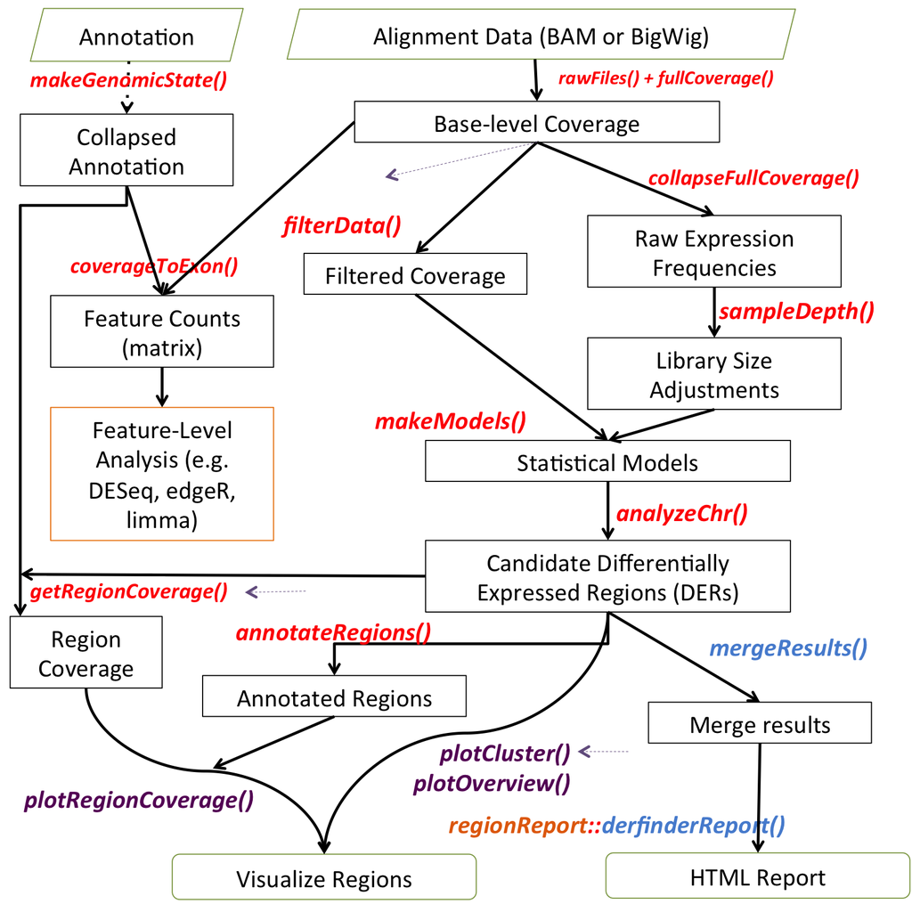

Flow chart of the different processing steps (black boxes) that can be carried out using *[derfinder](http://bioconductor.org/packages/release/bioc/html/derfinder.html)* and the functions that perform these actions (in red). Input and output is shown in green boxes. Functions in blue are those applied to the results from multiple chromosomes (`mergeResults()` and `derfinderReport`). *[regionReport](http://bioconductor.org/packages/release/bioc/html/regionReport.html)* functions are shown in orange while *[derfinderPlot](http://bioconductor.org/packages/release/bioc/html/derfinderPlot.html)* functions are shown in dark purple. Purple dotted arrow marks functions that require unfiltered base-level coverage.

## 14.2 `analyzeChr()` flow chart

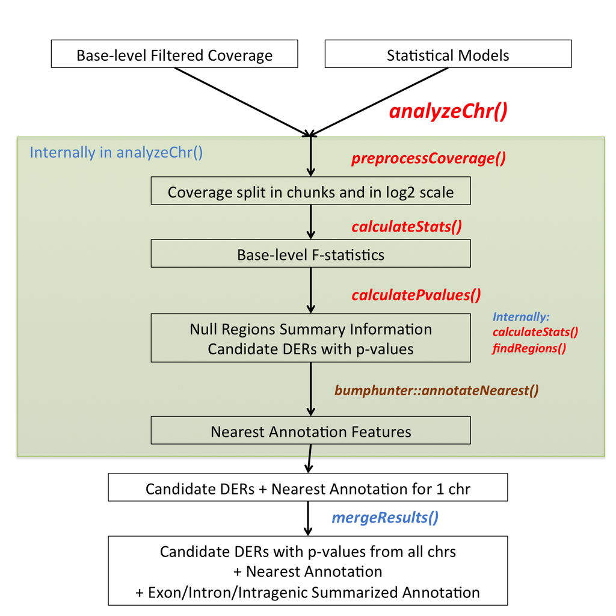

This figure shows in more detail the processing flow in `analyzeChr()`, which is the main function for identifying candidate differentially expressed regions (DERs) from the base-level F-statistics.

Many fine-tunning arguments can be passed to `analyzeChr()` to feed into the other functions. For example, you might want to use a smaller `chunksize` when pre-processing the coverage data (the default is 5 million): specially if you have hundreds of samples.

Another useful argument is `scalefac` (by default it’s 32) which controls the scaling factor to use before the log2 transformation.

Furthermore, you might want to specify `maxClusterGap` to control the maximum gap between two regions before they are considered to be part of the same cluster.

## 14.3 `regionMatrix()` flow chart

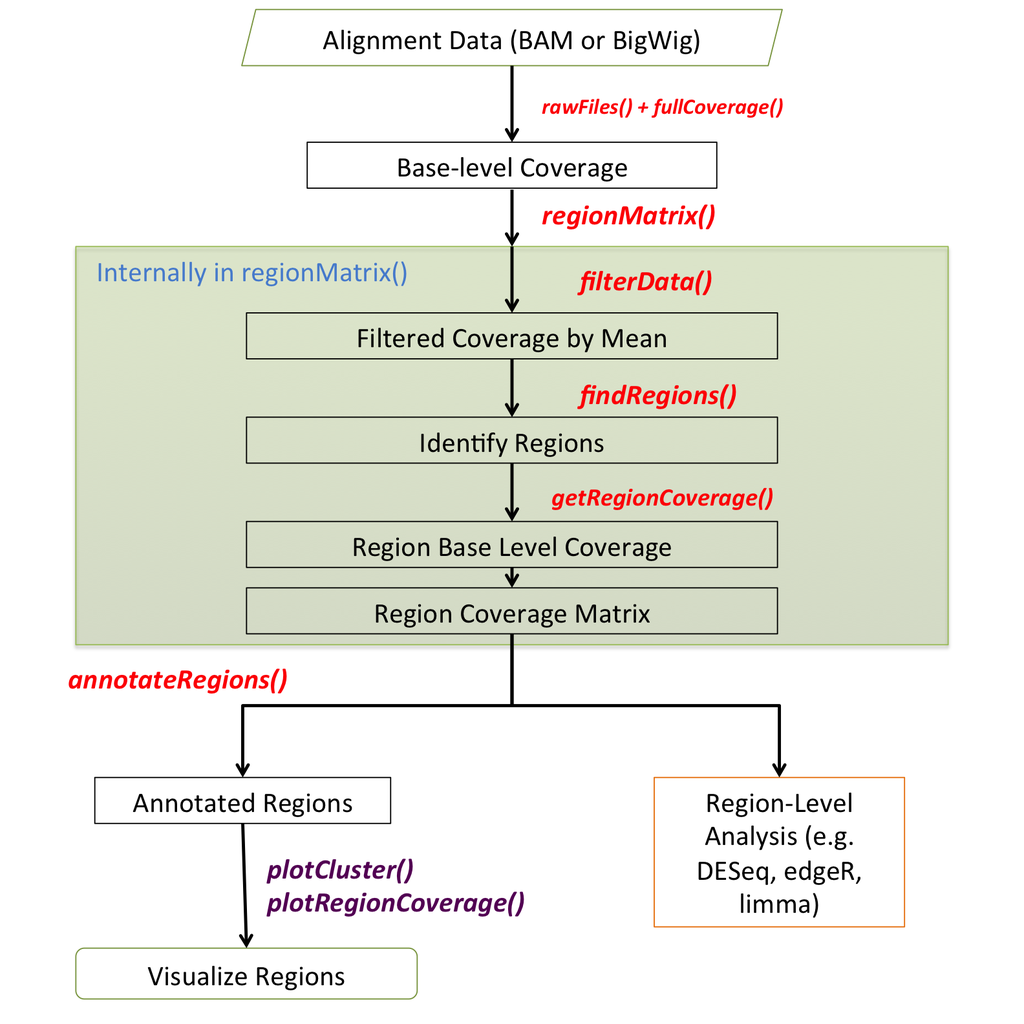

The above figure shows the functions used internally by `regionMatrix()` and processing steps for identifying expressed-regions. Overall, it is much simpler than `analyzeChr()`. The flow is even simpler in `railMatrix()`.

# 15 Base-level F-statistics projects

For each project where you will calculating base-level F-statistics, we recommend the following organization. You might be interested in a similar structure when using `regionMatrix()` if you have BAM files. The notable exception is when you are analyzing output data from [Rail](http://rail.bio) in which case you won’t be needing this type of organization. Remember that `railMatrix()` is much less computationally intensive than `analyzeChr()`.

## 15.1 File organization

This is our recommended file organization when using `analyzeChr()`.

```
ProjectDir
|-derCoverageInfo
|-derAnalysis
|---analysis01
|---analysis02
```

We start with a main project directory that has two initial directories. One for storing the coverage data, and one for storing each analysis: you might explore different models, cutoffs or other parameters.

You can then use `fullCoverage()`, save the result and also save the filtered coverage information for each chromosome separately. Doing so will result in the following structure.

```
ProjectDir
|-derCoverageInfo
|---Chr1Cov.Rdata
|---Chr2Cov.Rdata
...
|---ChrYCov.Rdata
|---fullCov.Rdata
|-derAnalysis
|---analysis01
|---analysis02
```

Next, you can use `analyzeChr()` for each of the chromosomes of a specific analysis (say *analysis01*). Doing so will create several Rdata files per chromosome as shown below. `bash` scripts can be useful if you wish to submit one cluster job per chromosome. In general, you will use the same model and group information for each chromosome, so saving the information can be useful.

```
ProjectDir
|-derCoverageInfo
|---Chr1Cov.Rdata
|---Chr2Cov.Rdata
...
|---ChrYCov.Rdata
|---fullCov.Rdata
|-derAnalysis
|---analysis01
|-----models.Rdata
|-----groupInfo.Rdata
|-----chr1/
|-------chunksDir/
|-------logs/
|-------annotation.Rdata
|-------coveragePrep.Rdata
|-------fstats.Rdata
|-------optionsStats.Rdata
|-------regions.Rdata
|-------timeinfo.Rdata
|-----chr2/
...
|-----chrY/
|---analysis02
```

Then use `mergeResults()` to pool together the results from all the chromosomes for a given analysis (here *analysis01*).

```
ProjectDir
|-derCoverageInfo
|---Chr1Cov.Rdata
|---Chr2Cov.Rdata
...
|---ChrYCov.Rdata
|---fullCov.Rdata
|-derAnalysis
|---analysis01
|-----logs/
|-----fullAnnotatedRegions.Rdata
|-----fullFstats.Rdata
|-----fullNullSummary.Rdata
|-----fullRegions.Rdata
|-----fullTime.Rdata
|-----optionsMerge.Rdata
|-----chr1/
|-------chunksDir/
|-------logs/
|-------annotation.Rdata
|-------coveragePrep.Rdata
|-------fstats.Rdata
|-------optionsStats.Rdata
|-------regions.Rdata
|-------timeinfo.Rdata
|-----chr2/
...
|-----chrY/
|---analysis02
```

Finally, you might want to use `derfinderReport()` from *[regionReport](http://bioconductor.org/packages/release/bioc/html/regionReport.html)* to create a HTML report of the results.

## 15.2 bash scripts

If you are following our recommended file organization for a base-level F-statistics DER finding analysis, you might be interested in the following `bash` scripts templates. Note that there are plenty of other solutions, such as writing a master `R` script and using *[BiocParallel](http://bioconductor.org/packages/release/bioc/html/BiocParallel.html)* to submit jobs and administer them for you. Check out the `BatchJobsParam()` for more information. If you want to use `bash` scripts, take a look below.

For interacting between `bash` and `R` we have found quite useful the *[getopt](http://cran.fhcrc.org/web/packages/getopt/index.html)* package. Here we include an example `R` script that is controlled by a `bash` script which submits a job for each chromosome to analyze for a given analysis.

The two files, *derfinderAnalysis.R* and *derAnalysis.sh* should live under the *derAnalysis* directory.

```
ProjectDir
|-derCoverageInfo
|---Chr1Cov.Rdata
|---Chr2Cov.Rdata
...
|---ChrYCov.Rdata
|---fullCov.Rdata
|-derAnalysis
|---derfinder-Analysis.R
|---derAnalysis.sh
|---analysis01
|---analysis02
```

Then, you can simply use:

```bash
cd /ProjectDir/derAnalysis
sh derAnalysis.sh analysis01
```

to run `analyzeChr()` on all your chromosomes.

### 15.2.1 derfinder-analysis.R

```r
## Run derfinder's analysis steps with timing info

## Load libraries
library("getopt")

## Available at http:/bioconductor.org/packages/derfinder
library("derfinder")

## Specify parameters
spec <- matrix(c(
    'DFfile', 'd', 1, "character", "path to the .Rdata file with the results from loadCoverage()",
    'chr', 'c', 1, "character", "Chromosome under analysis. Use X instead of chrX.",
    'mcores', 'm', 1, "integer", "Number of cores",
    'verbose' , 'v', 2, "logical", "Print status updates",
    'help' , 'h', 0, "logical", "Display help"
), byrow=TRUE, ncol=5)
opt <- getopt(spec)

## Testing the script
test <- FALSE
if(test) {
    ## Speficy it using an interactive R session and testing
    test <- TRUE
}

## Test values
if(test){
    opt <- NULL
    opt$DFfile <- "/ProjectDir/derCoverageInfo/chr21Cov.Rdata"
    opt$chr <- "21"
    opt$mcores <- 1
    opt$verbose <- NULL
}

## if help was asked for print a friendly message
## and exit with a non-zero error code
if (!is.null(opt$help)) {
    cat(getopt(spec, usage=TRUE))
    q(status=1)
}

## Default value for verbose = TRUE
if (is.null(opt$verbose)) opt$verbose <- TRUE

if(opt$verbose) message("Loading Rdata file with the output from loadCoverage()")
load(opt$DFfile)

## Make it easy to use the name later. Here I'm assuming the names were generated using output='auto' in loadCoverage()
eval(parse(text=paste0("data <- ", "chr", opt$chr, "CovInfo")))
eval(parse(text=paste0("rm(chr", opt$chr, "CovInfo)")))

## Just for testing purposes
if(test) {
    tmp <- data
    tmp$coverage <- tmp$coverage[1:1e6, ]
    library("IRanges")
    tmp$position[which(tmp$pos)[1e6 + 1]:length(tmp$pos)] <- FALSE
    data <- tmp
}

## Load the models
load("models.Rdata")

## Load group information
load("groupInfo.Rdata")


## Run the analysis with lowMemDir
analyzeChr(chr=opt$chr, coverageInfo=data, models=models, cutoffFstat=1e-06, cutoffType="theoretical", nPermute=1000, seeds=seq_len(1000), maxClusterGap=3000, groupInfo=groupInfo, subject="hg19", mc.cores=opt$mcores, lowMemDir=file.path(tempdir(), paste0("chr", opt$chr) , "chunksDir")), verbose=opt$verbose, chunksize=1e5)

## Done
if(opt$verbose) {
    print(proc.time())
    print(sessionInfo(), locale=FALSE)
}
```

Remember to modify the the script to fit your project.

### 15.2.2 derAnalysis.sh

```bash
#!/bin/sh

## Usage
# sh derAnalysis.sh analysis01

# Directories
MAINDIR=/ProjectDir
WDIR=${MAINDIR}/derAnalysis
DATADIR=${MAINDIR}/derCoverageInfo

# Define variables
SHORT='derA-01'
PREFIX=$1

# Construct shell files
for chrnum in 22 21 Y 20 19 18 17 16 15 14 13 12 11 10 9 8 X 7 6 5 4 3 2 1
do
    echo "Creating script for chromosome ${chrnum}"

    if [[ ${chrnum} == "Y" ]]
    then
        CORES=2
    else
        CORES=6
    fi

    chr="chr${chrnum}"
    outdir="${PREFIX}/${chr}"
    sname="${SHORT}.${PREFIX}.${chr}"
    cat > ${WDIR}/.${sname}.sh <<EOF
#!/bin/bash
#$ -cwd
#$ -m e
#$ -l mem_free=8G,h_vmem=10G,h_fsize=10G
#$ -N ${sname}
#$ -pe local ${CORES}

echo "**** Job starts ****"
date

# Create output directory
mkdir -p ${WDIR}/${outdir}
# Make logs directory
mkdir -p ${WDIR}/${outdir}/logs

# run derfinder-analysis.R
cd ${WDIR}/${PREFIX}/

# specific to our cluster
# see http://www.jhpce.jhu.edu/knowledge-base/environment-modules/
module load R/3.2.x
Rscript ${WDIR}/derfinder-analysis.R -d "${DATADIR}/${chr}Cov.Rdata" -c "${chrnum}" -m ${CORES} -v TRUE

# Move log files into the logs directory
mv ${WDIR}/${sname}.* ${WDIR}/${outdir}/logs/

echo "**** Job ends ****"
date
EOF
    call="qsub .${sname}.sh"
    $call
done
```

Your cluster might specify memory requirements differently and you might need to use fewer or more cores depending on your data set.

# 16 Expressed-regions projects

If you are using `regionMatrix()`, an organization similar to the one we mentioned for the base-level F-statistics implementation is recommended. If you have a very large number of samples, it might be best to store the coverage data separately by chromosome instead of a single `fullCov` object. This is help with the memory load since you can then write a script for loading the coverage data for the chromosome of interest and running `regionMatrix()` on it. Once all your jobs are done, merge the results from them.

If you are using `railMatrix()`, you don’t need any fancy setup. You only need the paths to the summary files and the sample files, all of which are assumed to be BigWig files.

# 17 Summary

We have illustrated how to identify candidate differentially expressed regions without using annotation by using `analyzeChr()`. Furthermore, we covered how to perform the expressed-region matrix analysis with `regionMatrix()` or `railMatrix()`. We also highlighted other uses of the *[derfinder](http://bioconductor.org/packages/release/bioc/html/derfinder.html)* package.

Latter sections of this vignette covered the most commonly used advanced arguments, details on how to load data, flow charts explaining the relationships between the functions, the recommended output organization, and example shell scripts for running the analysis.

# 18 Reproducibility

This package was made possible thanks to:

- R ([R Core Team, 2015](https://www.R-project.org/))
- *[AnnotationDbi](http://bioconductor.org/packages/release/bioc/html/AnnotationDbi.html)* (Pages, Carlson, Falcon, and Li, 2015)
- *[BiocParallel](http://bioconductor.org/packages/release/bioc/html/BiocParallel.html)* (Morgan, Obenchain, Lang, and Thompson, 2015)
- *[bumphunter](http://bioconductor.org/packages/release/bioc/html/bumphunter.html)* ([Jaffe, Murakami, Lee, Leek, et al., 2012](http://dx.doi.org/10.1093/ije/dyr238)) and (Jaffe, E, Murakami, Peter, et al., 2012)
- *[derfinderHelper](http://bioconductor.org/packages/release/bioc/html/derfinderHelper.html)*
- *[GenomeInfoDb](http://bioconductor.org/packages/release/bioc/html/GenomeInfoDb.html)* (Arora, Morgan, Carlson, and Pages, 2015)
- *[GenomicAlignments](http://bioconductor.org/packages/release/bioc/html/GenomicAlignments.html)* ([Lawrence, Huber, Pagès, Aboyoun, et al., 2013](http://www.ploscompbiol.org/article/info%3Adoi%2F10.1371%2Fjournal.pcbi.1003118))
- *[GenomicFeatures](http://bioconductor.org/packages/release/bioc/html/GenomicFeatures.html)* ([Lawrence, Huber, Pagès, Aboyoun, et al., 2013](http://www.ploscompbiol.org/article/info%3Adoi%2F10.1371%2Fjournal.pcbi.1003118))
- *[GenomicFiles](http://bioconductor.org/packages/release/bioc/html/GenomicFiles.html)* (Obenchain, Love, and Morgan, 2015)
- *[GenomicRanges](http://bioconductor.org/packages/release/bioc/html/GenomicRanges.html)* ([Lawrence, Huber, Pagès, Aboyoun, et al., 2013](http://www.ploscompbiol.org/article/info%3Adoi%2F10.1371%2Fjournal.pcbi.1003118))
- *[Hmisc](http://cran.fhcrc.org/web/packages/Hmisc/index.html)* ([Jr, with contributions from Charles Dupont, and many others., 2015](http://CRAN.R-project.org/package=Hmisc))
- *[IRanges](http://bioconductor.org/packages/release/bioc/html/IRanges.html)* ([Lawrence, Huber, Pagès, Aboyoun, et al., 2013](http://www.ploscompbiol.org/article/info%3Adoi%2F10.1371%2Fjournal.pcbi.1003118))
- *[qvalue](http://bioconductor.org/packages/release/bioc/html/qvalue.html)* (with contributions from Andrew J. Bass, Dabney, and Robinson, 2015)
- *[Rsamtools](http://bioconductor.org/packages/release/bioc/html/Rsamtools.html)* ([Morgan, Pagès, Obenchain, and Hayden, 2015](http://bioconductor.org/packages/release/bioc/html/Rsamtools.html))
- *[rtracklayer](http://bioconductor.org/packages/release/bioc/html/rtracklayer.html)* ([Lawrence, Gentleman, and Carey, 2009](http://bioinformatics.oxfordjournals.org/content/25/14/1841.abstract))
- *[S4Vectors](http://bioconductor.org/packages/release/bioc/html/S4Vectors.html)* (Pages, Lawrence, and Aboyoun, 2015)
- *[biovizBase](http://bioconductor.org/packages/release/bioc/html/biovizBase.html)* (Yin, Lawrence, and Cook, 2015)
- *[derfinderData](http://bioconductor.org/packages/release/data/experiment/html/derfinderData.html)* ([Collado-Torres, Jaffe, and Leek, 2015](https://github.com/lcolladotor/derfinderData))
- *[devtools](http://cran.fhcrc.org/web/packages/devtools/index.html)* ([Wickham and Chang, 2015](http://CRAN.R-project.org/package=devtools))
- *[ggplot2](http://cran.fhcrc.org/web/packages/ggplot2/index.html)* ([Wickham, 2009](http://had.co.nz/ggplot2/book))
- *[knitcitations](http://cran.fhcrc.org/web/packages/knitcitations/index.html)* ([Boettiger, 2015](http://CRAN.R-project.org/package=knitcitations))
- *[knitr](http://cran.fhcrc.org/web/packages/knitr/index.html)* ([Xie, 2014](http://www.crcpress.com/product/isbn/9781466561595))
- *[BiocStyle](http://bioconductor.org/packages/release/bioc/html/BiocStyle.html)* ([Morgan, Oleś, and Huber, 2015](https://github.com/Bioconductor/BiocStyle))
- *[rmarkdown](http://cran.fhcrc.org/web/packages/rmarkdown/index.html)* ([Allaire, Cheng, Xie, McPherson, et al., 2015](http://CRAN.R-project.org/package=rmarkdown))
- *[testthat](http://cran.fhcrc.org/web/packages/testthat/index.html)* ([Wickham, 2011](http://journal.r-project.org/archive/2011-1/RJournal_2011-1_Wickham.pdf))
- *[TxDb.Hsapiens.UCSC.hg19.knownGene](http://bioconductor.org/packages/release/data/annotation/html/TxDb.Hsapiens.UCSC.hg19.knownGene.html)* (Carlson and Maintainer, 2015)

Code for creating the vignette

```r
## Create the vignette
library('rmarkdown')
system.time(render('derfinder-users-guide.Rmd', 'BiocStyle::html_document'))

## Extract the R code
library('knitr')
knit('derfinder-users-guide.Rmd', tangle = TRUE)
```

```r
## Clean up
file.remove('derfinderUsersGuideRed.bib')
```

```
## [1] TRUE
```

```r
unlink('analysisResults', recursive = TRUE)
file.remove('HSB113.bw')
```

```
## [1] TRUE
```

```r
file.remove('meanChr21.bw')
```

```
## [1] TRUE
```

Date the vignette was generated.

```
## [1] "2015-11-11 18:50:51 EST"
```

Wallclock time spent generating the vignette.

```
## Time difference of 3.196 mins
```

```
##  setting  value
##  version  R version 3.2.2 (2015-08-14)
##  system   x86_64, darwin13.4.0
##  ui       X11
##  language (EN)
##  collate  en_US.UTF-8
##  tz       America/New_York
##  date     2015-11-11
```

```
## Packages ---------------------------------------------------------------------------------------------------------------
```

```
##  package                           * version     date       source
##  acepack                             1.3-3.3     2014-11-24 CRAN (R 3.2.0)
##  annotate                            1.48.0      2015-10-14 Bioconductor
##  AnnotationDbi                     * 1.32.0      2015-10-14 Bioconductor
##  bibtex                              0.4.0       2014-12-31 CRAN (R 3.2.0)
##  Biobase                           * 2.30.0      2015-10-14 Bioconductor
##  BiocGenerics                      * 0.16.1      2015-11-06 Bioconductor
##  BiocParallel                        1.4.0       2015-10-14 Bioconductor
##  BiocStyle                         * 1.8.0       2015-10-14 Bioconductor
##  biomaRt                             2.26.0      2015-10-14 Bioconductor
##  Biostrings                          2.38.0      2015-10-14 Bioconductor
##  bitops                              1.0-6       2013-08-17 CRAN (R 3.2.0)
##  bumphunter                        * 1.10.0      2015-10-14 Bioconductor
##  cluster                             2.0.3       2015-07-21 CRAN (R 3.2.2)
##  codetools                           0.2-14      2015-07-15 CRAN (R 3.2.2)
##  colorspace                          1.2-6       2015-03-11 CRAN (R 3.2.0)
##  DBI                               * 0.3.1       2014-09-24 CRAN (R 3.2.0)
##  derfinder                         * 1.5.9       2015-11-11 Bioconductor
##  derfinderData                     * 0.104.0     2015-10-15 Bioconductor
##  derfinderHelper                     1.4.1       2015-11-03 Bioconductor
##  DESeq2                            * 1.10.0      2015-10-14 Bioconductor
##  devtools                          * 1.9.1       2015-09-11 CRAN (R 3.2.0)
##  digest                              0.6.8       2014-12-31 CRAN (R 3.2.0)
##  doRNG                               1.6         2014-03-07 CRAN (R 3.2.0)
##  evaluate                            0.8         2015-09-18 CRAN (R 3.2.0)
##  foreach                           * 1.4.3       2015-10-13 CRAN (R 3.2.0)
##  foreign                             0.8-66      2015-08-19 CRAN (R 3.2.0)
##  formatR                             1.2.1       2015-09-18 CRAN (R 3.2.0)
##  Formula                             1.2-1       2015-04-07 CRAN (R 3.2.0)
##  futile.logger                       1.4.1       2015-04-20 CRAN (R 3.2.0)
##  futile.options                      1.0.0       2010-04-06 CRAN (R 3.2.0)
##  genefilter                          1.52.0      2015-10-14 Bioconductor
##  geneplotter                         1.48.0      2015-10-14 Bioconductor
##  GenomeInfoDb                      * 1.6.1       2015-11-03 Bioconductor
##  GenomicAlignments                   1.6.1       2015-10-22 Bioconductor
##  GenomicFeatures                   * 1.22.4      2015-11-05 Bioconductor
##  GenomicFiles                        1.6.0       2015-10-14 Bioconductor
##  GenomicRanges                     * 1.22.1      2015-11-06 Bioconductor
##  ggplot2                           * 1.0.1       2015-03-17 CRAN (R 3.2.0)
##  gridExtra                           2.0.0       2015-07-14 CRAN (R 3.2.0)
```

[output cut: 40 more lines]

```
##  Rsamtools                           1.22.0      2015-10-14 Bioconductor
##  RSQLite                           * 1.0.0       2014-10-25 CRAN (R 3.2.0)
##  rtracklayer                         1.30.1      2015-10-22 Bioconductor
##  S4Vectors                         * 0.8.1       2015-11-05 Bioconductor
##  scales                              0.3.0       2015-08-25 CRAN (R 3.2.0)
##  stringi                             1.0-1       2015-10-22 CRAN (R 3.2.0)
##  stringr                             1.0.0       2015-04-30 CRAN (R 3.2.0)
##  SummarizedExperiment              * 1.0.1       2015-11-06 Bioconductor
##  survival                            2.38-3      2015-07-02 CRAN (R 3.2.2)
##  TxDb.Hsapiens.UCSC.hg19.knownGene * 3.2.2       2015-10-15 Bioconductor
##  XML                                 3.98-1.3    2015-06-30 CRAN (R 3.2.0)
##  xtable                              1.8-0       2015-11-02 CRAN (R 3.2.0)
##  XVector                             0.10.0      2015-10-14 Bioconductor
##  yaml                                2.1.13      2014-06-12 CRAN (R 3.2.0)
##  zlibbioc                            1.16.0      2015-10-14 Bioconductor
```

# 19 Bibliography

This vignette was generated using *[BiocStyle](http://bioconductor.org/packages/release/bioc/html/BiocStyle.html)* ([Morgan, Oleś, and Huber, 2015](https://github.com/Bioconductor/BiocStyle)) with *[knitr](http://cran.fhcrc.org/web/packages/knitr/index.html)* ([Xie, 2014](http://www.crcpress.com/product/isbn/9781466561595)) and *[rmarkdown](http://cran.fhcrc.org/web/packages/rmarkdown/index.html)* ([Allaire, Cheng, Xie, McPherson, et al., 2015](http://CRAN.R-project.org/package=rmarkdown)) running behind the scenes.

Citations made with *[knitcitations](http://cran.fhcrc.org/web/packages/knitcitations/index.html)* ([Boettiger, 2015](http://CRAN.R-project.org/package=knitcitations)).

[1] J. Allaire, J. Cheng, Y. Xie, J. McPherson, et al. *rmarkdown: Dynamic Documents for R*. R package version 0.8.1. 2015. URL: http://CRAN.R-project.org/package=rmarkdown.

[2] J. D. S. with contributions from Andrew J. Bass, A. Dabney and D. Robinson. *qvalue: Q-value estimation for false discovery rate control*. R package version 2.2.0. 2015. URL: http://qvalue.princeton.edu/, http://github.com/jdstorey/qvalue.

[3] S. Arora, M. Morgan, M. Carlson and H. Pages. *GenomeInfoDb: Utilities for manipulating chromosome and other ‘seqname’ identifiers*. R package version 1.6.1. 2015.

[4] C. Boettiger. *knitcitations: Citations for Knitr Markdown Files*. R package version 1.0.6. 2015. URL: http://CRAN.R-project.org/package=knitcitations.

[5] BrainSpan. “Atlas of the Developing Human Brain [Internet]. Funded by ARRA Awards 1RC2MH089921-01, 1RC2MH090047-01, and 1RC2MH089929-01.” 2011. URL: http://developinghumanbrain.org.

[6] M. Carlson and B. P. Maintainer. *TxDb.Hsapiens.UCSC.hg19.knownGene: Annotation package for TxDb object(s)*. R package version 3.2.2. 2015.

[7] L. Collado-Torres, A. Jaffe and J. Leek. *derfinderData: Processed BigWigs from BrainSpan for examples*. R package version 0.104.0. 2015. URL: https://github.com/lcolladotor/derfinderData.

[8] A. C. Frazee, S. Sabunciyan, K. D. Hansen, R. A. Irizarry, et al. “Differential expression analysis of RNA-seq data at single-base resolution”. In: *Biostatistics* 15 (3) (2014), pp. 413-426. DOI: 10.1093/biostatistics/kxt053. URL: http://biostatistics.oxfordjournals.org/content/15/3/413.long.

[9] J. Hester. *knitrBootstrap: Knitr Bootstrap framework.* R package version 1.0.0. 2014. URL: https://github.com/jimhester/.

[10] A. E. Jaffe, P. Murakami, H. Lee, J. T. Leek, et al. “Bump hunting to identify differentially methylated regions in epigenetic epidemiology studies”. In: *International journal of epidemiology* 41.1 (2012), pp. 200–209. DOI: 10.1093/ije/dyr238.

[11] Jaffe, A. E, Murakami, Peter, et al. “Bump hunting to identify differentially methylated regions in epigenetic epidemiology studies”. In: *International Journal of Epidemiology* (2012).

[12] F. E. H. Jr, with contributions from Charles Dupont and many others. *Hmisc: Harrell Miscellaneous*. R package version 3.17-0. 2015. URL: http://CRAN.R-project.org/package=Hmisc.

[13] M. Lawrence, R. Gentleman and V. Carey. “rtracklayer: an R package for interfacing with genome browsers”. In: *Bioinformatics* 25 (2009), pp. 1841-1842. DOI: 10.1093/bioinformatics/btp328. URL: http://bioinformatics.oxfordjournals.org/content/25/14/1841.abstract.

[14] M. Lawrence, W. Huber, H. Pagès, P. Aboyoun, et al. “Software for Computing and Annotating Genomic Ranges”. In: *PLoS Computational Biology* 9 (8 2013). DOI: 10.1371/journal.pcbi.1003118. URL: http://www.ploscompbiol.org/article/info%3Adoi%2F10.1371%2Fjournal.pcbi.1003118}.

[15] M. Morgan, V. Obenchain, M. Lang and R. Thompson. *BiocParallel: Bioconductor facilities for parallel evaluation*. R package version 1.4.0. 2015.

[16] M. Morgan, A. Oleś and W. Huber. *BiocStyle: Standard styles for vignettes and other Bioconductor documents*. R package version 1.8.0. 2015. URL: https://github.com/Bioconductor/BiocStyle.

[17] M. Morgan, H. Pagès, V. Obenchain and N. Hayden. *Rsamtools: Binary alignment (BAM), FASTA, variant call (BCF), and tabix file import*. R package version 1.22.0. 2015. URL: http://bioconductor.org/packages/release/bioc/html/Rsamtools.html.

[18] V. Obenchain, M. Love and M. Morgan. *GenomicFiles: Distributed computing by file or by range*. R package version 1.6.0. 2015.

[19] H. Pages, M. Carlson, S. Falcon and N. Li. *AnnotationDbi: Annotation Database Interface*. R package version 1.32.0. 2015.

[20] H. Pages, M. Lawrence and P. Aboyoun. *S4Vectors: S4 implementation of vectors and lists*. R package version 0.8.1. 2015.

[21] R Core Team. *R: A Language and Environment for Statistical Computing*. R Foundation for Statistical Computing. Vienna, Austria, 2015. URL: https://www.R-project.org/.

[22] H. Wickham. *ggplot2: elegant graphics for data analysis*. Springer New York, 2009. ISBN: 978-0-387-98140-6. URL: http://had.co.nz/ggplot2/book.

[23] H. Wickham. “testthat: Get Started with Testing”. In: *The R Journal* 3 (2011), pp. 5–10. URL: http://journal.r-project.org/archive/2011-1/RJournal_2011-1_Wickham.pdf.

[24] H. Wickham and W. Chang. *devtools: Tools to Make Developing R Packages Easier*. R package version 1.9.1. 2015. URL: http://CRAN.R-project.org/package=devtools.

[25] Y. Xie. “knitr: A Comprehensive Tool for Reproducible Research in R”. In: *Implementing Reproducible Computational Research*. Ed. by V. Stodden, F. Leisch and R. D. Peng. ISBN 978-1466561595. Chapman and Hall/CRC, 2014. URL: http://www.crcpress.com/product/isbn/9781466561595.

[26] T. Yin, M. Lawrence and D. Cook. *biovizBase: Basic graphic utilities for visualization of genomic data.* R package version 1.18.0. 2015.